# Produire une étude du marché

## eboulis des valeurs propres

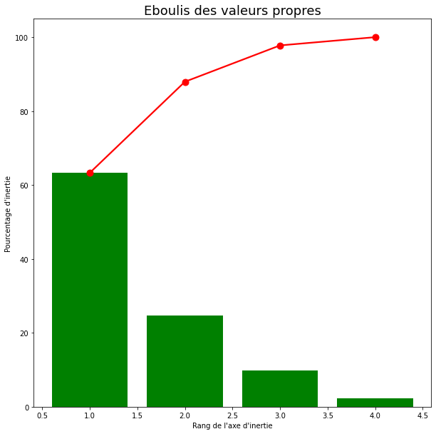

```python
fig, ax = plt.subplots(figsize=(10,10))
sns.set_context('talk')

scree = pca.explained_variance_ratio_*100
plt.bar(np.arange(len(scree))+1, scree, color='green')
plt.plot(np.arange(len(scree))+1, scree.cumsum(),marker='o', color='r')
plt.xlabel("Rang de l'axe d'inertie")
plt.ylabel("Pourcentage d'inertie")
plt.title("Eboulis des valeurs propres")
plt.show(block=False)
```

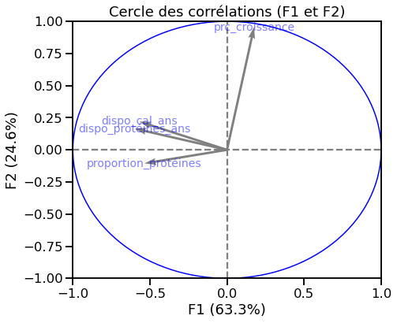

```python
pcs = pca.components_
display_circles(pcs, n_comp, pca, [(0,1)], labels = np.array(features))
```

```python
data_class_K2 = pd.DataFrame({'Area' : data_anal.index.tolist(),
                             'clusters_K2' : clusters_K2})
data_class_K2=data_class_K2.sort_values(['clusters_K2', 'Area'])
```

```python
data_mrg_K2 = pd.merge(data_anal, data_class_K2, on='Area')
data_mrg_K2 = data_mrg_K2.set_index('Area')
illustrative_var_K2 = data_mrg_K2['clusters_K2']
```

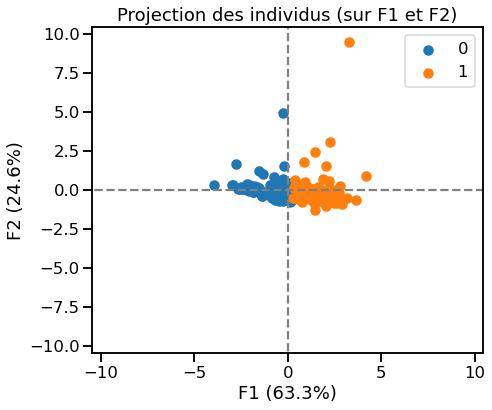

```python
X_projected = pca.transform(X_scaled)
display_factorial_planes(X_projected, n_comp, pca, [(0,1)], illustrative_var=illustrative_var_K2)
```

```python
data_mrg_K2.reset_index()
```

|  | Area | dispo_protéines_ans | proportion_protéines | dispo_cal_ans | prc_croissance | clusters_K2 |
| --- | --- | --- | --- | --- | --- | --- |
| 0 | Afghanistan | 21027.65 | 0.186252 | 8.274550e+08 | 8.75808 | 1 |
| 1 | Albania | 41175.65 | 0.540909 | 1.202675e+09 | -0.01429 | 0 |
| 2 | Algeria | 32959.50 | 0.272536 | 1.233335e+09 | 8.39219 | 0 |
| 3 | Angola | 19647.95 | 0.311536 | 8.924250e+08 | 9.93021 | 1 |
| 4 | Antigua and Barbuda | 29448.20 | 0.644522 | 9.008200e+08 | 0.00860 | 0 |
| ... | ... | ... | ... | ... | ... | ... |
| 170 | Venezuela (Bolivarian Republic of) | 18425.20 | 0.475832 | 8.124900e+08 | -5.15366 | 1 |
| 171 | Viet Nam | 31521.40 | 0.383164 | 1.065435e+09 | 9.45314 | 0 |
| 172 | Yemen | 18830.35 | 0.225237 | 7.329200e+08 | 6.63864 | 1 |
| 173 | Zambia | 21184.60 | 0.247760 | 8.219800e+08 | 4.98109 | 1 |
| 174 | Zimbabwe | 15622.00 | 0.275234 | 6.836450e+08 | 2.02207 | 1 |

175 rows × 6 columns

```python
data_gb_K2=data_mrg_K2.groupby("clusters_K2").mean()

data_gb_K2
```

| clusters_K2 | dispo_protéines_ans | proportion_protéines | dispo_cal_ans | prc_croissance |
| --- | --- | --- | --- | --- |
| 0 | 34795.523 | 0.536506 | 1.153061e+09 | 2.507770 |
| 1 | 22758.188 | 0.310135 | 9.076139e+08 | 7.627402 |

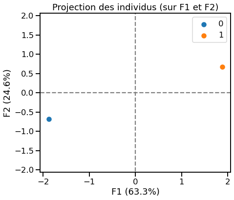

```python
X = data_gb_K2.values
std_scale = preprocessing.StandardScaler().fit(X)
X_scaled = std_scale.transform(X)

# Projection les clusters dans le premier plan factoriel
X_projected = pca.transform(X_scaled)
display_factorial_planes(X_projected, n_comp, pca, [(0,1)], illustrative_var=data_gb_K2.index)
```

```python
effectifs = data_class_K2["clusters_K2"].value_counts()
modalites = effectifs.index # l'index de effectifs contient les modalités

tab = pd.DataFrame(modalites, columns = ["clusters_K2"]) # création du tableau à partir des modalités
tab["n"] = effectifs.values
tab["f"] = tab["n"] / len(clusters_K2) # len(data) renvoie la taille de l'échantillon
tab["f"]
tab = tab.sort_values("clusters_K2") # tri des valeurs de la variable X (croissant)
tab
```

|  | clusters_K2 | n | f |
| --- | --- | --- | --- |
| 0 | 0 | 100 | 0.571429 |
| 1 | 1 | 75 | 0.428571 |

## 3 clusters

```python
# Nombre de clusters souhaités
n_clust3 = 3

# préparation des données pour le clustering
X = data_anal.values

# Réduire n'est ici pas nécessaire car les variables sont exprimées dans la même unité
# On prépare les données en faisant une normalisation (centrage-réduction)
#X_scaled = preprocessing.StandardScaler().fit(X)

X_scaled = preprocessing.StandardScaler().fit_transform(X)

# Clustering par K-means
km3 = KMeans(n_clusters=n_clust3)
km3.fit(X_scaled)

# Récupération des clusters attribués à chaque individu
clusters_K3 = km3.labels_
```

# PCA

```python
pca = decomposition.PCA(n_components=n_comp)
pca.fit(X_scaled)
```

```
PCA(n_components=4)
```

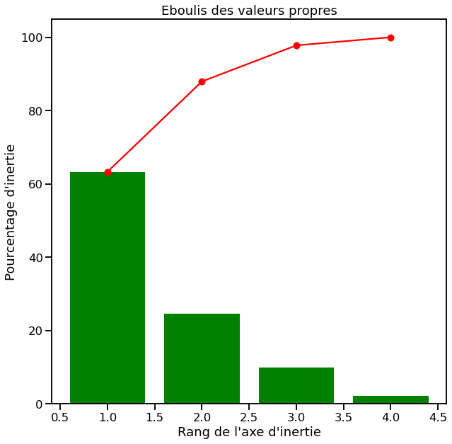

```python
fig, ax = plt.subplots(figsize=(10,10))
sns.set_context('talk')

scree = pca.explained_variance_ratio_*100
plt.bar(np.arange(len(scree))+1, scree, color='green')
plt.plot(np.arange(len(scree))+1, scree.cumsum(),marker='o', color='r')
plt.xlabel("Rang de l'axe d'inertie")
plt.ylabel("Pourcentage d'inertie")
plt.title("Eboulis des valeurs propres")
plt.show(block=False)
```

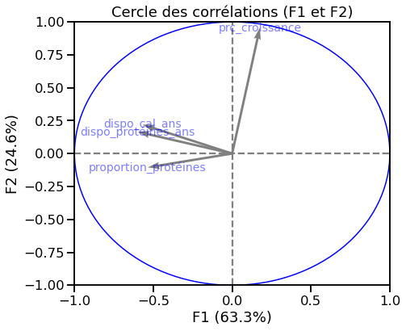

```python
pcs = pca.components_
display_circles(pcs, n_comp, pca, [(0,1)], labels = np.array(features))
```

```python
data_class_K3 = pd.DataFrame({'Area' : data_anal.index.tolist(),
                             'clusters_K3' : clusters_K3})
data_class_K3=data_class_K3.sort_values(['clusters_K3', 'Area'])
```

```python
data_mrg_K3 = pd.merge(data_anal, data_class_K3, on='Area')
data_mrg_K3 = data_mrg_K3.set_index('Area')
illustrative_var_K3 = data_mrg_K3['clusters_K3']
```

```python
data_mrg_K2.reset_index()
```

|  | Area | dispo_protéines_ans | proportion_protéines | dispo_cal_ans | prc_croissance | clusters_K2 |
| --- | --- | --- | --- | --- | --- | --- |
| 0 | Afghanistan | 21027.65 | 0.186252 | 8.274550e+08 | 8.75808 | 1 |
| 1 | Albania | 41175.65 | 0.540909 | 1.202675e+09 | -0.01429 | 0 |
| 2 | Algeria | 32959.50 | 0.272536 | 1.233335e+09 | 8.39219 | 0 |
| 3 | Angola | 19647.95 | 0.311536 | 8.924250e+08 | 9.93021 | 1 |
| 4 | Antigua and Barbuda | 29448.20 | 0.644522 | 9.008200e+08 | 0.00860 | 0 |
| ... | ... | ... | ... | ... | ... | ... |
| 170 | Venezuela (Bolivarian Republic of) | 18425.20 | 0.475832 | 8.124900e+08 | -5.15366 | 1 |
| 171 | Viet Nam | 31521.40 | 0.383164 | 1.065435e+09 | 9.45314 | 0 |
| 172 | Yemen | 18830.35 | 0.225237 | 7.329200e+08 | 6.63864 | 1 |
| 173 | Zambia | 21184.60 | 0.247760 | 8.219800e+08 | 4.98109 | 1 |
| 174 | Zimbabwe | 15622.00 | 0.275234 | 6.836450e+08 | 2.02207 | 1 |

175 rows × 6 columns

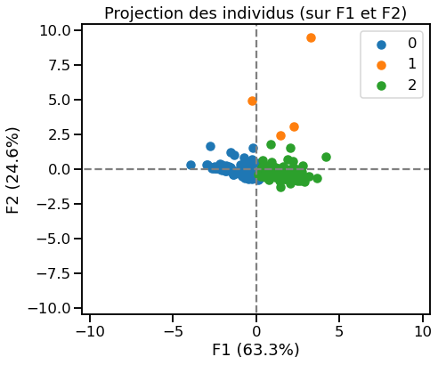

```python
X_projected = pca.transform(X_scaled)
display_factorial_planes(X_projected, n_comp, pca, [(0,1)], illustrative_var=illustrative_var_K3)
```

```python
data_gb_K3=data_mrg_K3.groupby("clusters_K3").mean()

data_gb_K3
```

| clusters_K3 | dispo_protéines_ans | proportion_protéines | dispo_cal_ans | prc_croissance |
| --- | --- | --- | --- | --- |
| 0 | 34827.331633 | 0.539192 | 1.153631e+09 | 1.870521 |
| 1 | 26974.412500 | 0.332657 | 9.954462e+08 | 75.103448 |
| 2 | 22814.250000 | 0.311496 | 9.087600e+08 | 4.645305 |

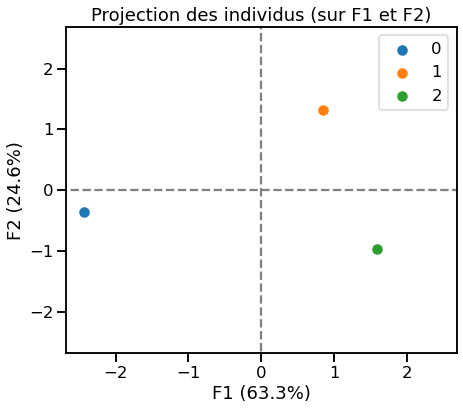

```python
X = data_gb_K3.values
std_scale = preprocessing.StandardScaler().fit(X)
X_scaled = std_scale.transform(X)

# Projection les clusters dans le premier plan factoriel
X_projected = pca.transform(X_scaled)
display_factorial_planes(X_projected, n_comp, pca, [(0,1)], illustrative_var=data_gb_K3.index)
```

```python
effectifs = data_class_K3["clusters_K3"].value_counts()
modalites = effectifs.index # l'index de effectifs contient les modalités

tab = pd.DataFrame(modalites, columns = ["clusters_K3"]) # création du tableau à partir des modalités
tab["n"] = effectifs.values
tab["f"] = tab["n"] / len(clusters_K3) # len(data) renvoie la taille de l'échantillon
tab["f"]
tab = tab.sort_values("clusters_K3") # tri des valeurs de la variable X (croissant)
tab
```

|  | clusters_K3 | n | f |
| --- | --- | --- | --- |
| 0 | 0 | 98 | 0.560000 |
| 2 | 1 | 4 | 0.022857 |
| 1 | 2 | 73 | 0.417143 |

```python
data_gb_K3=data_mrg_K3.groupby("clusters_K3").mean()

data_gb_K3
```

| clusters_K3 | dispo_protéines_ans | proportion_protéines | dispo_cal_ans | prc_croissance |
| --- | --- | --- | --- | --- |
| 0 | 34827.331633 | 0.539192 | 1.153631e+09 | 1.870521 |
| 1 | 26974.412500 | 0.332657 | 9.954462e+08 | 75.103448 |
| 2 | 22814.250000 | 0.311496 | 9.087600e+08 | 4.645305 |

## PCA sur K_means 4 clusters

```python
# Nombre de clusters souhaités
n_clust4= 4

# préparation des données pour le clustering
X = data_anal.values

# Réduire n'est ici pas nécessaire car les variables sont exprimées dans la même unité
# On prépare les données en faisant une normalisation (centrage-réduction)
#X_scaled = preprocessing.StandardScaler().fit(X)

X_scaled = preprocessing.StandardScaler().fit_transform(X)

# Clustering par K-means
km4 = KMeans(n_clusters=n_clust4)
km4.fit(X_scaled)

# Récupération des clusters attribués à chaque individu
clusters_K4 = km4.labels_
```

## PCA K_means avec 4 clusters

```python
pca = decomposition.PCA(n_components=n_comp)
pca.fit(X_scaled)
```

```
PCA(n_components=4)
```

```python
data_class_K4 = pd.DataFrame({'Area' : data_anal.index.tolist(),
                             'clusters_K4' : clusters_K4})
data_class_K4=data_class_K4.sort_values(['clusters_K4', 'Area'])
```

```python
data_mrg_K4 = pd.merge(data_anal, data_class_K4, on='Area')
data_mrg_K4 = data_mrg_K4.set_index('Area')
illustrative_var_K4 = data_mrg_K4['clusters_K4']
```

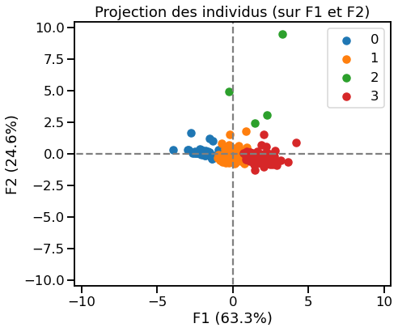

```python
X_projected = pca.transform(X_scaled)
display_factorial_planes(X_projected, n_comp, pca, [(0,1)], illustrative_var=illustrative_var_K4)
plt.savefig('Distribution_prop_prot')
```

```python
data_mrg_K4.reset_index()
```

|  | Area | dispo_protéines_ans | proportion_protéines | dispo_cal_ans | prc_croissance | clusters_K4 |
| --- | --- | --- | --- | --- | --- | --- |
| 0 | Afghanistan | 21027.65 | 0.186252 | 8.274550e+08 | 8.75808 | 3 |
| 1 | Albania | 41175.65 | 0.540909 | 1.202675e+09 | -0.01429 | 0 |
| 2 | Algeria | 32959.50 | 0.272536 | 1.233335e+09 | 8.39219 | 1 |
| 3 | Angola | 19647.95 | 0.311536 | 8.924250e+08 | 9.93021 | 3 |
| 4 | Antigua and Barbuda | 29448.20 | 0.644522 | 9.008200e+08 | 0.00860 | 1 |
| ... | ... | ... | ... | ... | ... | ... |
| 170 | Venezuela (Bolivarian Republic of) | 18425.20 | 0.475832 | 8.124900e+08 | -5.15366 | 3 |
| 171 | Viet Nam | 31521.40 | 0.383164 | 1.065435e+09 | 9.45314 | 1 |
| 172 | Yemen | 18830.35 | 0.225237 | 7.329200e+08 | 6.63864 | 3 |
| 173 | Zambia | 21184.60 | 0.247760 | 8.219800e+08 | 4.98109 | 3 |
| 174 | Zimbabwe | 15622.00 | 0.275234 | 6.836450e+08 | 2.02207 | 3 |

175 rows × 6 columns

```python
data_gb_K4=data_mrg_K4.groupby("clusters_K4").mean()

data_gb_K4
```

| clusters_K4 | dispo_protéines_ans | proportion_protéines | dispo_cal_ans | prc_croissance |
| --- | --- | --- | --- | --- |
| 0 | 38473.807692 | 0.571365 | 1.234065e+09 | 1.735096 |
| 1 | 29281.226119 | 0.477086 | 1.035276e+09 | 2.814539 |
| 2 | 26974.412500 | 0.332657 | 9.954462e+08 | 75.103448 |
| 3 | 21462.280769 | 0.267391 | 8.819312e+08 | 4.684985 |

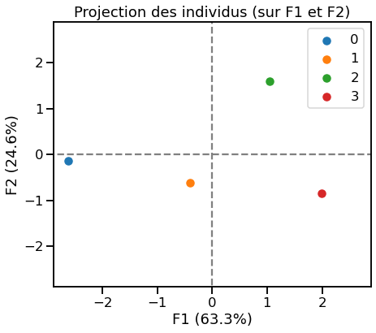

```python
X = data_gb_K4.values
std_scale = preprocessing.StandardScaler().fit(X)
X_scaled = std_scale.transform(X)

# Projection les clusters dans le premier plan factoriel
X_projected = pca.transform(X_scaled)
display_factorial_planes(X_projected, n_comp, pca, [(0,1)], illustrative_var=data_gb_K4.index)
```

```python
effectifs = data_class_K4["clusters_K4"].value_counts()
modalites = effectifs.index # l'index de effectifs contient les modalités

tab = pd.DataFrame(modalites, columns = ["clusters_K4"]) # création du tableau à partir des modalités
tab["n"] = effectifs.values
tab["f"] = tab["n"] / len(clusters_K4) # len(data) renvoie la taille de l'échantillon
tab["f"]
tab = tab.sort_values("clusters_K4") # tri des valeurs de la variable X (croissant)
tab
```

|  | clusters_K4 | n | f |
| --- | --- | --- | --- |
| 1 | 0 | 52 | 0.297143 |
| 0 | 1 | 67 | 0.382857 |
| 3 | 2 | 4 | 0.022857 |
| 2 | 3 | 52 | 0.297143 |

```python
pay_clust_2=data_mrg_K4.loc[data_mrg_K4.clusters_K4==3]
pay_clust_2
```

| Area | dispo_protéines_ans | proportion_protéines | dispo_cal_ans | prc_croissance | clusters_K4 |
| --- | --- | --- | --- | --- | --- |
| Afghanistan | 21027.65 | 0.186252 | 8.274550e+08 | 8.75808 | 3 |
| Angola | 19647.95 | 0.311536 | 8.924250e+08 | 9.93021 | 3 |
| Bangladesh | 22268.65 | 0.205704 | 9.522850e+08 | 16.91284 | 3 |
| Benin | 23071.65 | 0.237937 | 1.005210e+09 | 3.09846 | 3 |
| Burkina Faso | 29419.00 | 0.284119 | 1.002290e+09 | 5.58232 | 3 |
| Burundi | 15855.60 | 0.074125 | 6.716000e+08 | 3.48355 | 3 |
| C?te d'Ivoire | 21918.25 | 0.251124 | 1.046820e+09 | 6.31760 | 3 |
| Cambodia | 24236.00 | 0.293072 | 9.884200e+08 | 2.40383 | 3 |
| Cameroon | 26181.45 | 0.247038 | 1.004115e+09 | 6.50194 | 3 |
| Central African Republic | 18881.45 | 0.433018 | 6.982450e+08 | 0.70345 | 3 |
| Comoros | 19582.25 | 0.262628 | 8.431500e+08 | 0.18430 | 3 |
| Congo | 19425.30 | 0.497557 | 7.957000e+08 | 1.33664 | 3 |
| Democratic People's Republic of Korea | 19662.55 | 0.195285 | 7.376650e+08 | 1.19779 | 3 |
| Democratic Republic of the Congo | 9490.00 | 0.124231 | 7.022600e+08 | 26.69327 | 3 |
| Djibouti | 24834.60 | 0.234127 | 1.017985e+09 | 0.14824 | 3 |
| Eswatini | 22002.20 | 0.320338 | 9.292900e+08 | 0.11476 | 3 |
| Ethiopia | 26061.00 | 0.185994 | 8.931550e+08 | 28.24490 | 3 |
| Gambia | 23297.95 | 0.341846 | 9.121350e+08 | 0.66205 | 3 |
| Ghana | 22790.60 | 0.275945 | 1.119090e+09 | 6.45637 | 3 |
| Guatemala | 25155.80 | 0.320807 | 9.146900e+08 | 3.32879 | 3 |
| Guinea | 21013.05 | 0.204099 | 1.023825e+09 | 3.46774 | 3 |
| Guinea-Bissau | 15837.35 | 0.260890 | 8.176000e+08 | 0.46158 | 3 |
| Haiti | 17830.25 | 0.232139 | 7.657700e+08 | 1.40812 | 3 |
| Honduras | 22834.40 | 0.353261 | 9.785650e+08 | 1.58509 | 3 |
| Iraq | 23958.60 | 0.223492 | 9.515550e+08 | 8.80819 | 3 |
| Jordan | 24455.00 | 0.380299 | 9.497300e+08 | 1.79475 | 3 |
| Kenya | 22323.40 | 0.254088 | 7.916850e+08 | 11.71423 | 3 |
| Lao People's Democratic Republic | 27991.85 | 0.251663 | 1.012510e+09 | 1.08472 | 3 |
| Lesotho | 23188.45 | 0.316701 | 8.234400e+08 | 0.16794 | 3 |
| Liberia | 15089.10 | 0.264877 | 7.887650e+08 | 1.16747 | 3 |
| Madagascar | 15665.80 | 0.220177 | 6.887550e+08 | 6.91801 | 3 |
| Malawi | 26002.60 | 0.209714 | 9.544750e+08 | 4.73021 | 3 |
| Mozambique | 17932.45 | 0.197232 | 7.873050e+08 | 8.46986 | 3 |
| Namibia | 24031.60 | 0.363761 | 9.052000e+08 | 0.45668 | 3 |
| Nepal | 27123.15 | 0.180864 | 1.044630e+09 | 4.63033 | 3 |
| Nicaragua | 23933.05 | 0.314321 | 9.588550e+08 | 0.80655 | 3 |
| Rwanda | 21954.75 | 0.185536 | 8.113950e+08 | 3.21009 | 3 |
| Sao Tome and Principe | 19669.85 | 0.324364 | 8.767300e+08 | 0.03939 | 3 |
| Senegal | 23480.45 | 0.261153 | 9.471750e+08 | 4.34968 | 3 |
| Sierra Leone | 18060.20 | 0.249798 | 8.515450e+08 | 1.61727 | 3 |
| Solomon Islands | 19235.50 | 0.293928 | 8.756350e+08 | 0.16818 | 3 |
| Sri Lanka | 25060.90 | 0.279202 | 1.009590e+09 | 1.00731 | 3 |
| Syrian Arab Republic | 26119.40 | 0.288988 | 1.013240e+09 | -1.50621 | 3 |
| Tajikistan | 26283.65 | 0.330371 | 8.975350e+08 | 2.20567 | 3 |
| Timor-Leste | 18005.45 | 0.234137 | 8.216150e+08 | 0.24716 | 3 |
| Togo | 20786.75 | 0.271817 | 8.727150e+08 | 1.90619 | 3 |
| Uganda | 17092.95 | 0.239163 | 7.741650e+08 | 15.62448 | 3 |
| United Republic of Tanzania | 22206.60 | 0.211538 | 8.614000e+08 | 16.53099 | 3 |
| Venezuela (Bolivarian Republic of) | 18425.20 | 0.475832 | 8.124900e+08 | -5.15366 | 3 |
| Yemen | 18830.35 | 0.225237 | 7.329200e+08 | 6.63864 | 3 |
| Zambia | 21184.60 | 0.247760 | 8.219800e+08 | 4.98109 | 3 |
| Zimbabwe | 15622.00 | 0.275234 | 6.836450e+08 | 2.02207 | 3 |

```python
pay_clust_1=data_mrg_K4.loc[data_mrg_K4.clusters_K4==0]
pay_clust_1
```

| Area | dispo_protéines_ans | proportion_protéines | dispo_cal_ans | prc_croissance | clusters_K4 |
| --- | --- | --- | --- | --- | --- |
| Albania | 41175.65 | 0.540909 | 1.202675e+09 | -0.01429 | 0 |
| Argentina | 39598.85 | 0.643746 | 1.206325e+09 | 4.24010 | 0 |
| Armenia | 35525.45 | 0.493168 | 1.119820e+09 | 0.06954 | 0 |
| Australia | 39226.55 | 0.676468 | 1.238445e+09 | 3.13532 | 0 |
| Austria | 40018.60 | 0.601696 | 1.349405e+09 | 0.71487 | 0 |
| Belarus | 32890.15 | 0.560426 | 1.190265e+09 | 0.02386 | 0 |
| Belgium | 35726.20 | 0.581018 | 1.376050e+09 | 0.62430 | 0 |
| Bosnia and Herzegovina | 36186.10 | 0.378051 | 1.208515e+09 | -0.27600 | 0 |
| Brazil | 35353.90 | 0.572992 | 1.200485e+09 | 16.35500 | 0 |
| Canada | 39368.90 | 0.563786 | 1.287355e+09 | 3.42467 | 0 |
| Croatia | 33572.70 | 0.608284 | 1.129310e+09 | -0.26452 | 0 |
| Czechia | 31528.70 | 0.607432 | 1.194645e+09 | 0.24643 | 0 |
| Denmark | 43033.50 | 0.679813 | 1.240270e+09 | 0.19852 | 0 |
| Estonia | 37934.45 | 0.625036 | 1.163620e+09 | 0.03530 | 0 |
| Finland | 43267.10 | 0.642905 | 1.220560e+09 | 0.11205 | 0 |
| France | 39566.00 | 0.592343 | 1.269470e+09 | 1.48002 | 0 |
| French Polynesia | 35259.00 | 0.681470 | 1.054850e+09 | 0.01577 | 0 |
| Germany | 38423.55 | 0.611380 | 1.297210e+09 | 4.66009 | 0 |
| Greece | 40018.60 | 0.586830 | 1.228955e+09 | -0.47204 | 0 |
| Hungary | 32747.80 | 0.574565 | 1.223115e+09 | -0.22324 | 0 |
| Iceland | 53162.25 | 0.722485 | 1.331885e+09 | 0.02320 | 0 |
| Ireland | 42741.50 | 0.613834 | 1.412915e+09 | 0.65411 | 0 |
| Israel | 46902.50 | 0.613385 | 1.300860e+09 | 1.37668 | 0 |
| Italy | 38387.05 | 0.533137 | 1.262900e+09 | -0.46410 | 0 |
| Kazakhstan | 37828.60 | 0.540042 | 1.221655e+09 | 2.39599 | 0 |
| Kuwait | 36646.00 | 0.495717 | 1.257425e+09 | 0.81213 | 0 |
| Latvia | 35076.50 | 0.582830 | 1.178950e+09 | -0.22638 | 0 |
| Lithuania | 45475.35 | 0.613051 | 1.244650e+09 | -0.44150 | 0 |
| Luxembourg | 39427.30 | 0.621829 | 1.270565e+09 | 0.12335 | 0 |
| Malta | 40292.35 | 0.575414 | 1.234795e+09 | 0.01315 | 0 |
| Mongolia | 35430.55 | 0.679098 | 1.040980e+09 | 0.56430 | 0 |
| Montenegro | 41347.20 | 0.612906 | 1.277865e+09 | 0.00246 | 0 |
| Morocco | 36963.55 | 0.277772 | 1.243190e+09 | 4.47838 | 0 |
| Netherlands | 38591.45 | 0.643904 | 1.209245e+09 | 0.38213 | 0 |
| New Zealand | 35605.75 | 0.564941 | 1.172380e+09 | 0.41097 | 0 |
| Norway | 42281.60 | 0.596167 | 1.244285e+09 | 0.41636 | 0 |
| Poland | 38609.70 | 0.557005 | 1.292830e+09 | -0.31588 | 0 |
| Portugal | 42453.15 | 0.642507 | 1.259980e+09 | -0.32334 | 0 |
| Republic of Korea | 35821.10 | 0.546974 | 1.259250e+09 | 0.75291 | 0 |
| Romania | 39858.00 | 0.497253 | 1.307430e+09 | -1.47855 | 0 |
| Russian Federation | 37726.40 | 0.534733 | 1.225305e+09 | 2.03956 | 0 |
| Seychelles | 34985.25 | 0.540845 | 1.134420e+09 | 0.00678 | 0 |
| Slovenia | 35178.70 | 0.537248 | 1.161795e+09 | 0.01443 | 0 |
| Spain | 40047.80 | 0.627415 | 1.219830e+09 | 0.45430 | 0 |
| Sweden | 38379.75 | 0.637851 | 1.157415e+09 | 0.66742 | 0 |
| Switzerland | 35463.40 | 0.630403 | 1.232240e+09 | 0.69807 | 0 |
| Tunisia | 36339.40 | 0.290478 | 1.274580e+09 | 1.31758 | 0 |
| Turkey | 40401.85 | 0.354413 | 1.365100e+09 | 12.23638 | 0 |
| United Kingdom of Great Britain and Northern Ireland | 38379.75 | 0.570804 | 1.224210e+09 | 4.14223 | 0 |
| United States of America | 41964.05 | 0.651387 | 1.408535e+09 | 20.11509 | 0 |
| Uruguay | 31984.95 | 0.549469 | 1.166905e+09 | 0.12644 | 0 |
| Uzbekistan | 36463.50 | 0.433333 | 1.175665e+09 | 5.16459 | 0 |

```python
pay_clust_1_res=pay_clust_1.reset_index()
```

```python
pay_clust_1_res.Area.unique()
```

```
array(['Albania', 'Argentina', 'Armenia', 'Australia', 'Austria',
       'Belarus', 'Belgium', 'Bosnia and Herzegovina', 'Brazil', 'Canada',
       'Croatia', 'Czechia', 'Denmark', 'Estonia', 'Finland', 'France',
       'French Polynesia', 'Germany', 'Greece', 'Hungary', 'Iceland',
       'Ireland', 'Israel', 'Italy', 'Kazakhstan', 'Kuwait', 'Latvia',
       'Lithuania', 'Luxembourg', 'Malta', 'Mongolia', 'Montenegro',
       'Morocco', 'Netherlands', 'New Zealand', 'Norway', 'Poland',
       'Portugal', 'Republic of Korea', 'Romania', 'Russian Federation',
       'Seychelles', 'Slovenia', 'Spain', 'Sweden', 'Switzerland',
       'Tunisia', 'Turkey',
       'United Kingdom of Great Britain and Northern Ireland',
       'United States of America', 'Uruguay', 'Uzbekistan'], dtype=object)
```

# pour un group de 5

```python
# Nombre de clusters souhaités
n_clust5 = 5

# préparation des données pour le clustering
X = data_anal.values

# Réduire n'est ici pas nécessaire car les variables sont exprimées dans la même unité
# On prépare les données en faisant une normalisation (centrage-réduction)
#X_scaled = preprocessing.StandardScaler().fit(X)

X_scaled = preprocessing.StandardScaler().fit_transform(X)

# Clustering par K-means
km5 = KMeans(n_clusters=n_clust5)
km5.fit(X_scaled)

# Récupération des clusters attribués à chaque individu
clusters_K5 = km5.labels_
```

## PCA K_means sur 5 clusters

```python
pca = decomposition.PCA(n_components=n_comp)
pca.fit(X_scaled)
```

```
PCA(n_components=4)
```

```python
data_class_K5 = pd.DataFrame({'Area' : data_anal.index.tolist(),
                             'clusters_K5' : clusters_K5})
data_class_K5=data_class_K5.sort_values(['clusters_K5', 'Area'])
```

```python
data_mrg_K5 = pd.merge(data_anal, data_class_K5, on='Area')
data_mrg_K5 = data_mrg_K5.set_index('Area')
illustrative_var_K5 = data_mrg_K5['clusters_K5']
```

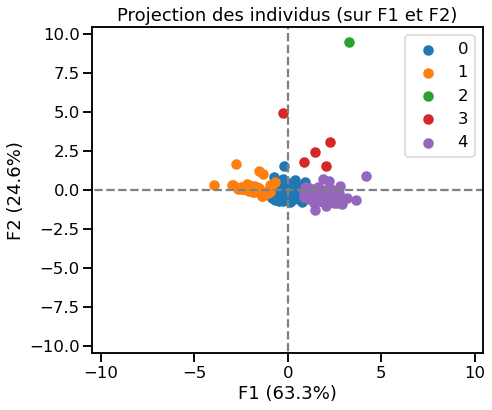

```python
X_projected = pca.transform(X_scaled)
display_factorial_planes(X_projected, n_comp, pca, [(0,1)], illustrative_var=illustrative_var_K5)
```

```python
data_mrg_K5.reset_index()
```

|  | Area | dispo_protéines_ans | proportion_protéines | dispo_cal_ans | prc_croissance | clusters_K5 |
| --- | --- | --- | --- | --- | --- | --- |
| 0 | Afghanistan | 21027.65 | 0.186252 | 8.274550e+08 | 8.75808 | 4 |
| 1 | Albania | 41175.65 | 0.540909 | 1.202675e+09 | -0.01429 | 1 |
| 2 | Algeria | 32959.50 | 0.272536 | 1.233335e+09 | 8.39219 | 0 |
| 3 | Angola | 19647.95 | 0.311536 | 8.924250e+08 | 9.93021 | 4 |
| 4 | Antigua and Barbuda | 29448.20 | 0.644522 | 9.008200e+08 | 0.00860 | 0 |
| ... | ... | ... | ... | ... | ... | ... |
| 170 | Venezuela (Bolivarian Republic of) | 18425.20 | 0.475832 | 8.124900e+08 | -5.15366 | 4 |
| 171 | Viet Nam | 31521.40 | 0.383164 | 1.065435e+09 | 9.45314 | 0 |
| 172 | Yemen | 18830.35 | 0.225237 | 7.329200e+08 | 6.63864 | 4 |
| 173 | Zambia | 21184.60 | 0.247760 | 8.219800e+08 | 4.98109 | 4 |
| 174 | Zimbabwe | 15622.00 | 0.275234 | 6.836450e+08 | 2.02207 | 4 |

175 rows × 6 columns

```python
data_gb_K5=data_mrg_K5.groupby("clusters_K5").mean()

data_gb_K5
```

| clusters_K5 | dispo_protéines_ans | proportion_protéines | dispo_cal_ans | prc_croissance |
| --- | --- | --- | --- | --- |
| 0 | 29343.167164 | 0.476060 | 1.034208e+09 | 2.447174 |
| 1 | 38473.807692 | 0.571365 | 1.234065e+09 | 1.735096 |
| 2 | 23725.000000 | 0.255231 | 9.340350e+08 | 139.654950 |
| 3 | 27100.520000 | 0.322855 | 1.002947e+09 | 43.839908 |
| 4 | 21211.172000 | 0.268684 | 8.792996e+08 | 4.195840 |

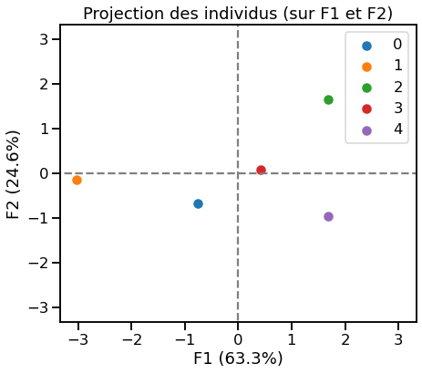

```python
X = data_gb_K5.values
std_scale = preprocessing.StandardScaler().fit(X)
X_scaled = std_scale.transform(X)

# Projection les clusters dans le premier plan factoriel
X_projected = pca.transform(X_scaled)
display_factorial_planes(X_projected, n_comp, pca, [(0,1)], illustrative_var=data_gb_K5.index)
```

```python
effectifs = data_class_K3["clusters_K3"].value_counts()
modalites = effectifs.index # l'index de effectifs contient les modalités

tab = pd.DataFrame(modalites, columns = ["clusters_K3"]) # création du tableau à partir des modalités
tab["n"] = effectifs.values
tab["f"] = tab["n"] / len(clusters_K3) # len(data) renvoie la taille de l'échantillon
tab["f"]
tab = tab.sort_values("clusters_K3") # tri des valeurs de la variable X (croissant)
tab
```

|  | clusters_K3 | n | f |
| --- | --- | --- | --- |
| 0 | 0 | 98 | 0.560000 |
| 2 | 1 | 4 | 0.022857 |
| 1 | 2 | 73 | 0.417143 |

# Pour un groupe de 6

```python
# Nombre de clusters souhaités
n_clust6 = 6

# préparation des données pour le clustering
X = data_anal.values

# Réduire n'est ici pas nécessaire car les variables sont exprimées dans la même unité
# On prépare les données en faisant une normalisation (centrage-réduction)
#X_scaled = preprocessing.StandardScaler().fit(X)

X_scaled = preprocessing.StandardScaler().fit_transform(X)

# Clustering par K-means
km6 = KMeans(n_clusters=n_clust6)
km6.fit(X_scaled)

# Récupération des clusters attribués à chaque individu
clusters_K6 = km6.labels_
```

# PCA K-means pour 6 clusters

```python
pca = decomposition.PCA(n_components=n_comp)
pca.fit(X_scaled)
```

```
PCA(n_components=4)
```

```python
data_class_K6 = pd.DataFrame({'Area' : data_anal.index.tolist(),
                             'clusters_K6' : clusters_K6})
data_class_K6=data_class_K6.sort_values(['clusters_K6', 'Area'])
```

```python
data_mrg_K6 = pd.merge(data_anal, data_class_K6, on='Area')
data_mrg_K6 = data_mrg_K6.set_index('Area')
illustrative_var_K6 = data_mrg_K6['clusters_K6']
```

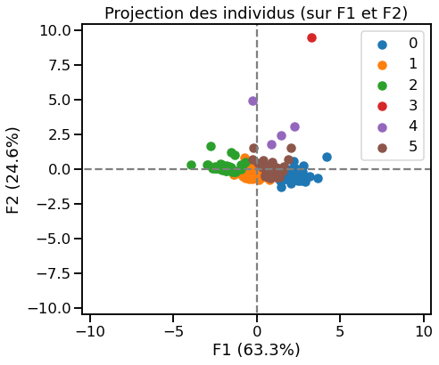

```python
X_projected = pca.transform(X_scaled)
display_factorial_planes(X_projected, n_comp, pca, [(0,1)], illustrative_var=illustrative_var_K6)
```

```python
data_mrg_K2.reset_index()
```

|  | Area | dispo_protéines_ans | proportion_protéines | dispo_cal_ans | prc_croissance | clusters_K2 |
| --- | --- | --- | --- | --- | --- | --- |
| 0 | Afghanistan | 21027.65 | 0.186252 | 8.274550e+08 | 8.75808 | 1 |
| 1 | Albania | 41175.65 | 0.540909 | 1.202675e+09 | -0.01429 | 0 |
| 2 | Algeria | 32959.50 | 0.272536 | 1.233335e+09 | 8.39219 | 0 |
| 3 | Angola | 19647.95 | 0.311536 | 8.924250e+08 | 9.93021 | 1 |
| 4 | Antigua and Barbuda | 29448.20 | 0.644522 | 9.008200e+08 | 0.00860 | 0 |
| ... | ... | ... | ... | ... | ... | ... |
| 170 | Venezuela (Bolivarian Republic of) | 18425.20 | 0.475832 | 8.124900e+08 | -5.15366 | 1 |
| 171 | Viet Nam | 31521.40 | 0.383164 | 1.065435e+09 | 9.45314 | 0 |
| 172 | Yemen | 18830.35 | 0.225237 | 7.329200e+08 | 6.63864 | 1 |
| 173 | Zambia | 21184.60 | 0.247760 | 8.219800e+08 | 4.98109 | 1 |
| 174 | Zimbabwe | 15622.00 | 0.275234 | 6.836450e+08 | 2.02207 | 1 |

175 rows × 6 columns

```python
data_gb_K6=data_mrg_K6.groupby("clusters_K6").mean()
```

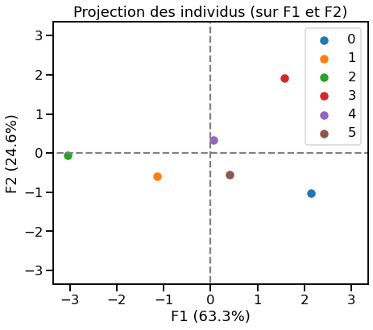

```python
X = data_gb_K6.values
std_scale = preprocessing.StandardScaler().fit(X)
X_scaled = std_scale.transform(X)

# Projection les clusters dans le premier plan factoriel
X_projected = pca.transform(X_scaled)
display_factorial_planes(X_projected, n_comp, pca, [(0,1)], illustrative_var=data_gb_K6.index)
```

```python
effectifs = data_class_K6["clusters_K6"].value_counts()
modalites = effectifs.index # l'index de effectifs contient les modalités

tab = pd.DataFrame(modalites, columns = ["clusters_K6"]) # création du tableau à partir des modalités
tab["n"] = effectifs.values
tab["f"] = tab["n"] / len(clusters_K6) # len(data) renvoie la taille de l'échantillon
tab["f"]
tab = tab.sort_values("clusters_K6") # tri des valeurs de la variable X (croissant)
tab
```

|  | clusters_K6 | n | f |
| --- | --- | --- | --- |
| 3 | 0 | 27 | 0.154286 |
| 0 | 1 | 57 | 0.325714 |
| 1 | 2 | 46 | 0.262857 |
| 5 | 3 | 1 | 0.005714 |
| 4 | 4 | 4 | 0.022857 |
| 2 | 5 | 40 | 0.228571 |

## la methode du coude

```python
from sklearn import metrics
from scipy.spatial.distance import cdist

OMP_NUM_THREADS=1
```

```python
X = data_anal.values
OMP_NUM_THREADS=1
```

```python
X
```

[output not shown]

[output cut: 295 more lines]

```
         1.26440000e-01],
       [ 3.64635000e+04,  4.33333333e-01,  1.17566500e+09,
         5.16459000e+00],
       [ 2.34038000e+04,  4.29819089e-01,  9.42430000e+08,
         7.17000000e-02],
       [ 1.84252000e+04,  4.75832013e-01,  8.12490000e+08,
        -5.15366000e+00],
       [ 3.15214000e+04,  3.83163502e-01,  1.06543500e+09,
         9.45314000e+00],
       [ 1.88303500e+04,  2.25237449e-01,  7.32920000e+08,
         6.63864000e+00],
       [ 2.11846000e+04,  2.47760165e-01,  8.21980000e+08,
         4.98109000e+00],
       [ 1.56220000e+04,  2.75233645e-01,  6.83645000e+08,
         2.02207000e+00]])
```

```python
distortions = []
inertias = []
mapping1 = {}
mapping2 = {}
K = range(1,10)

for k in K:

    kmeanModel = KMeans(n_clusters=k).fit(X)
    kmeanModel.fit(X)

    distortions.append(sum(np.min(cdist(X, kmeanModel.cluster_centers_,
                      'euclidean'),axis=1)) / X.shape[0])
    inertias.append(kmeanModel.inertia_)

    mapping1[k] = sum(np.min(cdist(X, kmeanModel.cluster_centers_,
                 'euclidean'),axis=1)) / X.shape[0]
    mapping2[k] = kmeanModel.inertia_
```

```python
for key,val in mapping1.items():
    print(str(key)+' : '+str(val))
```

```
1 : 134611738.255313
2 : 77376259.92976378
3 : 50110224.129035
4 : 39389358.977053784
5 : 33554067.174461562
6 : 28538227.434210762
7 : 24166162.57404426
8 : 20719898.81478436
9 : 18373629.761113416
```

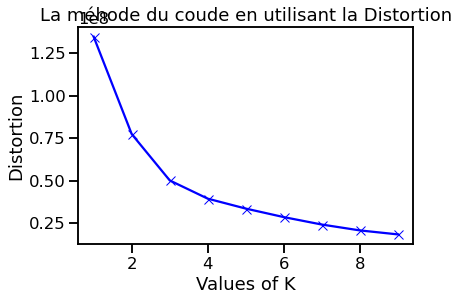

```python
plt.plot(K, distortions, 'bx-')

plt.xlabel('Values of K')
plt.ylabel('Distortion')
plt.title('La méhode du coude en utilisant la Distortion')
plt.savefig("p5_figures/méthode_coude.jpg")
plt.show()
```

on remarque que l'inertie comence a se stabeliser a parir de K=4 donc je prend K=4 pour mes tests et pour choisir les pays

# un test d'adéquation : parmi les 4 variables, ou parmi d'autres variables que vous trouverez pertinentes, trouvez une variable dont la loi est normale ;

## Test d'adéquation pour la variable disponibilité en protéines

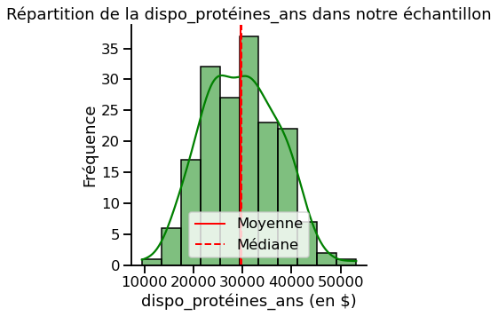

```python
sns.displot(data=data_mrg_K4, x="dispo_protéines_ans", kde=True ,color='green')
plt.axvline(x=data_mrg_K4["dispo_protéines_ans"].mean(), label='Moyenne', linestyle='-', linewidth=2, color='red')
plt.axvline(x=data_mrg_K4["dispo_protéines_ans"].median(), label='Médiane', linestyle='--', linewidth=2 ,color='red')
plt.xlabel('dispo_protéines_ans (en $)')
plt.ylabel('Fréquence')
plt.title('Répartition de la dispo_protéines_ans dans notre échantillon')

plt.legend()

plt.savefig("p5_figures/Répartition_dispo_protéines_ans.jpg")

plt.show()
```

d'apres le schemat on remarque que la distribuion a l\'aire normale

```python
data_gb_means=data_mrg_K4.groupby("clusters_K4").mean()
data_gb_means
```

| clusters_K4 | dispo_protéines_ans | proportion_protéines | dispo_cal_ans | prc_croissance |
| --- | --- | --- | --- | --- |
| 0 | 38473.807692 | 0.571365 | 1.234065e+09 | 1.735096 |
| 1 | 29281.226119 | 0.477086 | 1.035276e+09 | 2.814539 |
| 2 | 26974.412500 | 0.332657 | 9.954462e+08 | 75.103448 |
| 3 | 21462.280769 | 0.267391 | 8.819312e+08 | 4.684985 |

```python
clusters_K4
```

```
array([3, 0, 1, 3, 1, 0, 0, 0, 0, 1, 1, 3, 1, 0, 0, 1, 3, 1, 0, 1, 0, 1,
       3, 3, 3, 1, 3, 3, 0, 3, 1, 1, 2, 1, 3, 3, 1, 0, 1, 1, 0, 3, 3, 0,
       3, 1, 1, 1, 1, 1, 0, 3, 3, 1, 0, 0, 0, 1, 3, 1, 0, 3, 0, 1, 3, 3,
       3, 1, 3, 3, 0, 0, 2, 1, 1, 3, 0, 0, 0, 1, 1, 3, 0, 3, 1, 0, 1, 3,
       0, 1, 3, 3, 1, 0, 0, 3, 3, 1, 1, 1, 0, 1, 1, 1, 0, 0, 0, 3, 1, 3,
       3, 0, 1, 0, 3, 1, 2, 1, 0, 1, 2, 1, 1, 1, 1, 1, 0, 0, 0, 1, 0, 0,
       3, 1, 1, 1, 1, 3, 1, 3, 1, 0, 3, 1, 0, 3, 1, 0, 3, 1, 1, 0, 0, 3,
       3, 1, 3, 3, 1, 0, 0, 1, 3, 1, 0, 3, 0, 0, 0, 1, 3, 1, 3, 3, 3])
```

```python
from scipy import stats
rng = np.random.default_rng()
```

on effectue un Test de Kolmogorov-Smirnov test la distribution non parametriques parametrique c est quant il nya pas d'ypothese a verifier simplification de test de normalité

```python
stats.kstest(data_mrg_K4["dispo_protéines_ans"],list(np.random.normal(np.mean(data_mrg_K4["dispo_protéines_ans"]), np.std(data_mrg_K4["dispo_protéines_ans"]), 1000)))
```

```
KstestResult(statistic=0.08057142857142857, pvalue=0.27246002342936315)
```

la p value etant superieur à 5% pour ce iveau de test on ne peux pas rejetter l'ypothése nul, donc l'échatillion suit une lois normale

```python
#pour etre plus sur on effectue un test de shapiro
stats.shapiro(data_mrg_K4['dispo_protéines_ans'])
```

```
ShapiroResult(statistic=0.9916048049926758, pvalue=0.4014256000518799)
```

Le resultat confirme celui du Kstest donc on peux pas rejeter l'ypothése nul, l'echantillon suit une lois normale

## Test d'adequation pour la variable pourcentage de croissance de la population

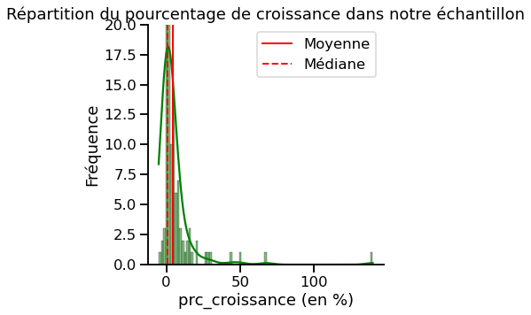

```python
sns.displot(data=data_mrg_K4, x="prc_croissance", kde=True ,color='green')

plt.axvline(x=data_anal["prc_croissance"].mean(), label='Moyenne', linestyle='-', linewidth=2, color='red')
plt.axvline(x=data_anal["prc_croissance"].median(), label='Médiane', linestyle='--', linewidth=2 ,color='red')
plt.xlabel('prc_croissance (en %)')
plt.ylabel('Fréquence')
plt.title('Répartition du pourcentage de croissance dans notre échantillon')
plt.ylim(0,20)
plt.legend()


plt.savefig('p5_figures/Distribution.jpg')

plt.show()
```

```python
#pour etre plus sur on effectue un test de shapiro
stats.shapiro(data_mrg_K4['prc_croissance'])
```

```
ShapiroResult(statistic=0.372137188911438, pvalue=2.5014438122216776e-24)
```

la p value etant inferuieur a 5% pour ce iveau de test on peut rejeter l'ypothése nul, donc l'échatillion ne suit pas une lois normale

# Un test de comparaison de deux populations (dans le cas gaussien)

# T-test

Le test d'égalité des variances : {H0: σ21=σ22 H1: σ21≠σ22

```python
data_var= pd.DataFrame({'Area' : data_mrg_K4.index.tolist(),
                             'clusters' : clusters})
data_var
```

|  | Area | clusters |
| --- | --- | --- |
| 0 | Afghanistan | 3 |
| 1 | Albania | 1 |
| 2 | Algeria | 2 |
| 3 | Angola | 3 |
| 4 | Antigua and Barbuda | 4 |
| ... | ... | ... |
| 170 | Venezuela (Bolivarian Republic of) | 4 |
| 171 | Viet Nam | 2 |
| 172 | Yemen | 3 |
| 173 | Zambia | 3 |
| 174 | Zimbabwe | 3 |

175 rows × 2 columns

```python
data_mrg_K4.reset_index().head(3)
```

|  | Area | dispo_protéines_ans | proportion_protéines | dispo_cal_ans | prc_croissance | clusters_K4 |
| --- | --- | --- | --- | --- | --- | --- |
| 0 | Afghanistan | 21027.65 | 0.186252 | 8.274550e+08 | 8.75808 | 3 |
| 1 | Albania | 41175.65 | 0.540909 | 1.202675e+09 | -0.01429 | 0 |
| 2 | Algeria | 32959.50 | 0.272536 | 1.233335e+09 | 8.39219 | 1 |

```python
data_eff1=data_mrg_K4.loc[data_mrg_K4.clusters_K4==1]
data_eff2=data_mrg_K4.loc[data_mrg_K4.clusters_K4==3]
```

```python
data_var1=data_eff1.dispo_protéines_ans
data_var2=data_eff2.dispo_protéines_ans
```

comparaison des variables

```python
data_rest=data_mrg.reset_index('Area')
```

Avant que le test t puisse être effectué, il faut tester les hypothèses. D'abord pour tester l'homogénéité des variances. Pour ce faire, j'utiliserai le test d'homogénéité de la variance de Levene.

```python
stats.levene(data_var1,data_var2)
```

```
LeveneResult(statistic=0.9622124006895807, pvalue=0.3286541179253809)
```

la p value etant superieur à 5% pour ce iveau de test on ne rejete pas l'ypothése nulle qui suppose que les variances sont égales donc on continue les autres étapes du test. Le test n'est pas significatif, c'est-à-dire il y a une homogénéité des variances . Si le test devait être significatif, une alternative viable serait d'effectuer un test t de Welch. on continue les eapes suivanes pour tester l'hypothèse de normalité. Tout d'abord, je vais les vérifier visuellement.Cela peut être fait visuellement avec un histogramme et/ou sous forme de graphique q-q, et en utilisant le test de Shapiro-Wilk Le test d'égalité des moyennes : {H0:μ1=μ2 H1:μ1<>μ2

[figure not shown]

```python
data_eff1['dispo_protéines_ans'].plot(kind="hist", title="proportion_protéines des pays du cluster1")
plt.xlabel("dispo_protéines_ans")
plt.savefig('p5_figures/dispo_protéines_ans')
```

[output not shown]

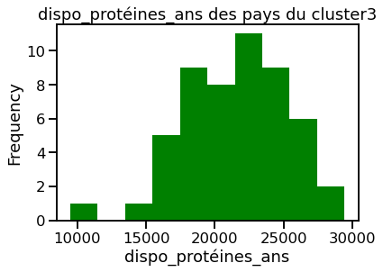

```python
data_eff2['dispo_protéines_ans'].plot(kind="hist", title="dispo_protéines_ans des pays du cluster3", color="green")
plt.xlabel("dispo_protéines_ans")

plt.savefig('p5_figures/dispo_protéines_ans-c3')
plt.show
```

D'après l'apparence de l'histogramme, chaque variable semble être distribuée assez normalement. Voyons à quoi cela ressemble sur un graphique q-q, pour avoir une idée de la normalité en visualisant les données sous forme de graphique q-q

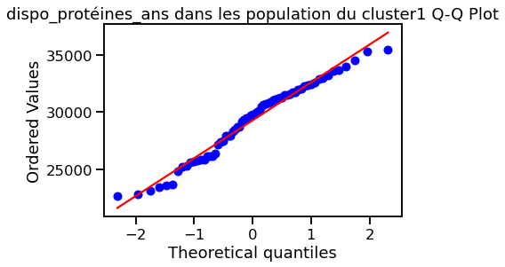

```python
stats.probplot(data_eff1['dispo_protéines_ans'], dist="norm", plot=plt)
plt.title("dispo_protéines_ans dans les population du cluster1 Q-Q Plot")
plt.figure(figsize = (10,10))
plt.savefig("p5_figures/normalitéC3.jpg")
plt.show()
```

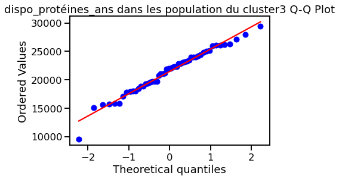

```python
stats.probplot(data_eff2['dispo_protéines_ans'], dist="norm", plot=plt)
plt.title("dispo_protéines_ans dans les population du cluster3 Q-Q Plot")
plt.figure(figsize = (10,10))
plt.savefig("p5_figures/normalitéC4.jpg")
plt.show()
```

Il y a un certain écart par rapport à la normalité dans le diagramme q-q, mais cela ne semble pas être une grande violation. Dans l'ensemble, les données semblent avoir une normaliténous allons tester statistiquement en utilisant le test de normalité de Shapiro-Wilk.

```python
stats.shapiro(data_eff1['dispo_protéines_ans'])
```

```
ShapiroResult(statistic=0.9690171480178833, pvalue=0.09285737574100494)
```

```python
stats.shapiro(data_eff2['dispo_protéines_ans'])
```

```
ShapiroResult(statistic=0.9788655638694763, pvalue=0.47880813479423523)
```

Aucun des tests de normalité n'est significatif (p_value>5%), ce qui signifie qu'aucune des variables ne viole pas l'hypothèse de normalité.

On continue pour effectuer le test t indépendant

```python
stats.ttest_ind(data_eff1['dispo_protéines_ans'], data_eff2['dispo_protéines_ans'], equal_var=True)
```

```
Ttest_indResult(statistic=11.904277661676698, pvalue=6.819949158307224e-22)
```

Le résultats du test t indépendant est significatifs ! Par conséquent, on peut rejeter l'hypothèse nulle à l'appui de l'alternative. on conclue a une difference des moyens entre les populations des deux cluseters 1 et 3 on conclue a une diference en dispo_protéines_ans moyenne entre les populations des deux cluseters 1 et 3 on a la p_value largement <5% un resultat signifiant ce qui nous mène a rejeter l'ypothése H0 en faveur de l'ypothese alternative,

## analyser les pays choisis

```python
pay_clus1=data_mrg_K4.loc[data_mrg_K4.clusters_K4==2]
pay_clus1
```

[output not shown]

```python
data_mrg_K4
```

[output not shown]

175 rows × 5 columns

```python
pay_clust_2=data_mrg_K4.loc[data_mrg_K4.clusters_K4==3]
pay_clust_2
```

[output not shown]

```python
pay_clus1.Area.unique()
```

[output not shown]